# Movies_project

## 6. Process `Awards` column

The variable `Awards` describes nominations and awards in text format. Convert it to 2 numeric columns, the first capturing the number of wins, and the second capturing nominations. Replace the `Awards` column with these new columns, and then study the relationship of `Gross` revenue with respect to them.

```r
# Convert Awards to 2 numeric columns: wins and nominations

# Deal with the most common "XX win" or "XX nomination" pattern
# set other cases to 0
pattern = "[0-9]* win"
Wins = sapply(1:nrow(df2), function(x) regmatches(
  df2$Awards[x],regexpr(pattern, df2$Awards[x])))
df2$wins = sapply(1:nrow(df2), function(x) ifelse(
  length(Wins[[x]]), as.numeric(strsplit(Wins[[x]]," ")[[1]][1]), 0))

pattern = "[0-9]* nomina"
Nominations = sapply(1:nrow(df2), function(x) regmatches(
  df2$Awards[x], regexpr(pattern, df2$Awards[x])))

df2$nominations = sapply(1:nrow(df2), function(x) ifelse(
  length(Nominations[[x]]), as.numeric(
    strsplit(Nominations[[x]]," ")[[1]][1]), 0))

# Deal with the 2nd most common "Won xx" or "Nominated for xx" pattern
# set other cases to 0
pattern = "Won [0-9]*"
Wons = sapply(1:nrow(df2), function(x)
  regmatches(df2$Awards[x], regexpr(pattern, df2$Awards[x])))
df2$wins = df2$wins + sapply(1:nrow(df2), function(x)
  ifelse(length(Wons[[x]]),
         as.numeric(strsplit(Wons[[x]]," ")[[1]][2]), 0))

pattern = "Nominated for [0-9]*"
Nominated = sapply(1:nrow(df2), function(x) regmatches(
  df2$Awards[x], regexpr(pattern, df2$Awards[x])))

df2$nominations = df2$nominations +
  sapply(1:nrow(df2), function(x) ifelse(length(Nominated[[x]]),
    as.numeric(strsplit(Nominated[[x]]," ")[[1]][3]), 0))

# Results
print(paste0("Rows with valid wins: ",
             sum(df2$wins!=0, na.rm = TRUE)))
```

```
## [1] "Rows with valid wins: 8830"
```

```r
print(paste0("Rows with nominations: ",
             sum(df2$nominations!=0, na.rm = TRUE)))
```

```
## [1] "Rows with nominations: 9271"
```

**Analysis**: The awards strings were parsed using regular expression. There are two major steps. First, the most common pattern “X wins” and “X nominations” were addressed, the numbers were retrieved and stored in two columns, wins and nominations, in the dataframe. After that, the second most common pattern: “Won X and”Nominated for X" were addressed, and the numbers were added to the previous two coloumns. After the processing, 8830 rows have valid wins, and 9271 rows have valid nominations.

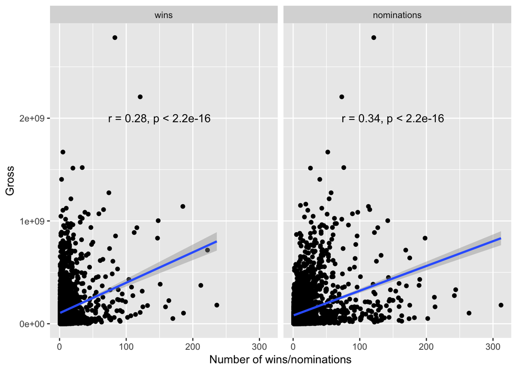

```r
# Plot Gross revenue against wins and nominations

# First set 0 win or nomination to NA
df2$wins[df2$wins==0] = NA
df2$nominations[df2$nominations==0] = NA

# Melt wins and nominations together
temp = melt(df2, measure.vars = c("wins", "nominations"),
            id.vars = c("Gross"))

ggplot(data = temp, aes(x=value, y=Gross),na.rm = TRUE) +
  geom_point(na.rm = TRUE) +
  geom_smooth(method = lm, na.rm = TRUE) +
  stat_cor(method = "pearson", label.x = 150,
           label.y = 2000000000, na.rm = TRUE) +
  facet_grid(.~ variable) +
  labs(x="Number of wins/nominations")
```

**Q**: How does the gross revenue vary by number of awards won and nominations received?

**A**: In general, there are positive correlation between wins/nominations and gross revenue, indicating movies with more awards or nominations are likely to have higher gross revenue. Nevertheless, these correllations are not very strong.

## 7. Movie ratings from IMDb and Rotten Tomatoes

There are several variables that describe ratings, including IMDb ratings (`imdbRating` represents average user ratings and `imdbVotes` represents the number of user ratings), and multiple Rotten Tomatoes ratings (represented by several variables pre-fixed by `tomato`). Read up on such ratings on the web (for example rottentomatoes.com/about and www.imdb.com/help/show_leaf?votestopfaq).

Investigate the pairwise relationships between these different descriptors using graphs.

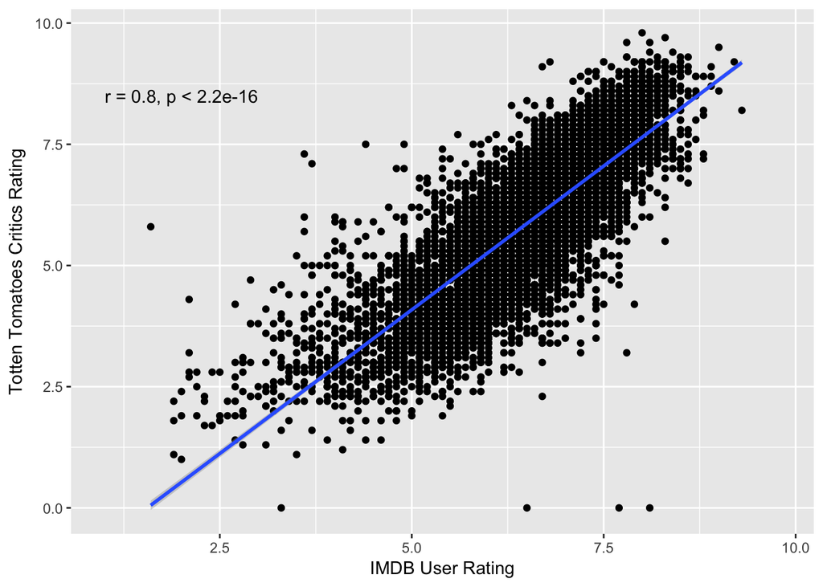

```r
# Illustrate how ratings from IMDb and Rotten Tomatoes are related

# User rating of IMDB vs. Critics rating from Rotten Tomato
ggplot(data = df2, aes(x = imdbRating, y = tomatoRating)) +
  geom_point(na.rm = TRUE) +
  geom_smooth(method = lm, na.rm = TRUE) +
  labs(x="IMDB User Rating", y="Totten Tomatoes Critics Rating") +
  stat_cor(method = "pearson", label.x = 2, label.y = 8.5, na.rm = TRUE)
```

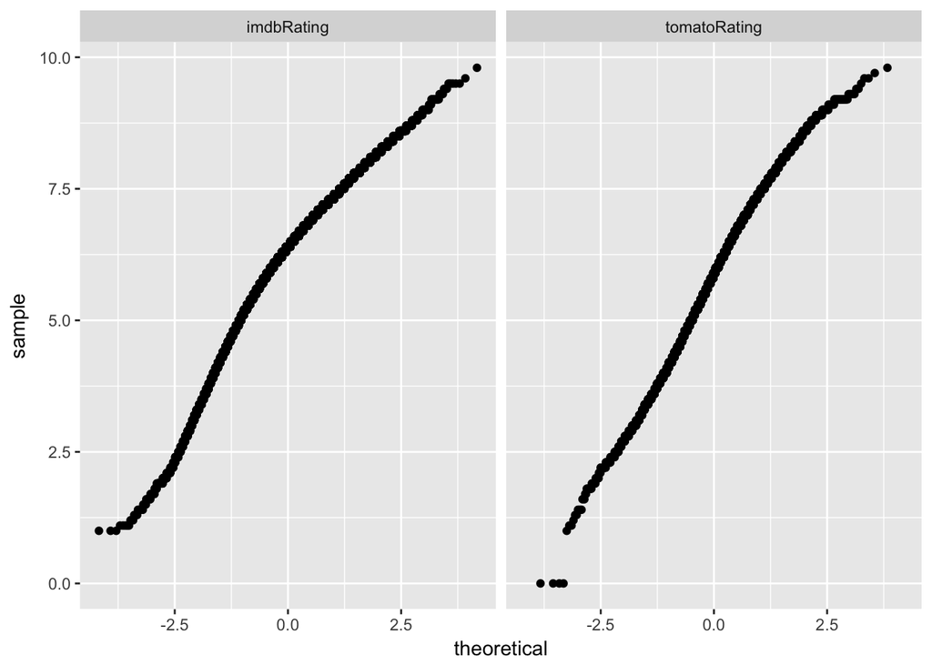

```r
temp = melt(data = df2, id.vars = "Title", measure.vars = c("imdbRating", "tomatoRating"))
temp = na.omit(temp)
ggplot(data = na.omit(temp), aes(sample = value)) +
  stat_qq() +
  facet_grid(.~variable)
```

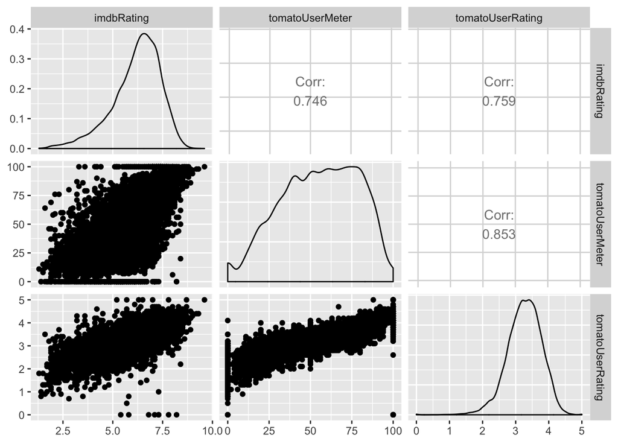

```r
# User rating of IMDB vs. User rating from Rotten Tomato
DF = df2[,c("imdbRating", "tomatoUserMeter", "tomatoUserRating")]
ggpairs(na.omit(DF))
```

**Q**: Comment on the similarities and differences between the user ratings of IMDb and the critics ratings of Rotten Tomatoes.

**A**: In general, user rating of IMDB and the cirtics ratings of Rotten Tomatoes are similar in a way that they have a strong positive correlation (r = 0.8). One difference is that the tomato critics rating tends to be slightly lower than the user rating of IMDB. Also, the QQPlot demonstrates that the critics ratings of Rotten Tomatoes more closely approximate a shifted Gaussian distribution, while the imdb ratings are closer to a non-linear S-shape.

## 8. Ratings and awards

These ratings typically reflect the general appeal of the movie to the public or gather opinions from a larger body of critics. Whereas awards are given by professional societies that may evaluate a movie on specific attributes, such as artistic performance, screenplay, sound design, etc.

Study the relationship between ratings and awards using graphs (awards here refers to wins and/or nominations).

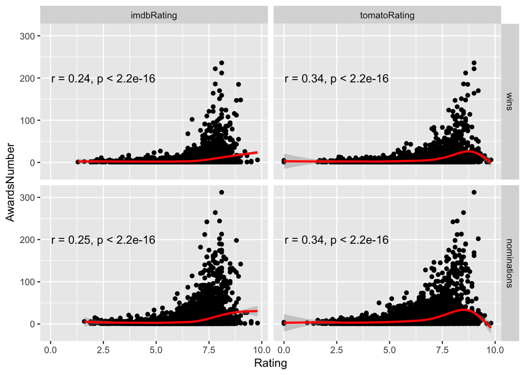

```r
# Show how ratings and awards are related
DF = melt(df2, measure.vars = c("wins", "nominations"),
            id.vars = c("imdbRating", "tomatoRating"))
names(DF) = c("imdbRating","tomatoRating","Awards","AwardsNumber")
DF2 = melt(DF, measure.vars = c("imdbRating","tomatoRating"),
           id.vars = c("Awards","AwardsNumber"))
names(DF2) = c("Awards","AwardsNumber","RatingSource","Rating")

ggplot(na.omit(DF2), aes(x = Rating, y = AwardsNumber )) +
  geom_point() +
  geom_smooth(method = "auto" , na.rm = TRUE, color = "red") +
  facet_grid(Awards ~ RatingSource) +
  stat_cor(method = "pearson", label.x = 2.5, label.y = 200)
```

**Analysis**: Both user rating from IMDB and critics rating from tomato are not very good in terms of predicting the success of a moive (defined by wining awards). The correlations are quite weak.

## 9. Other insights

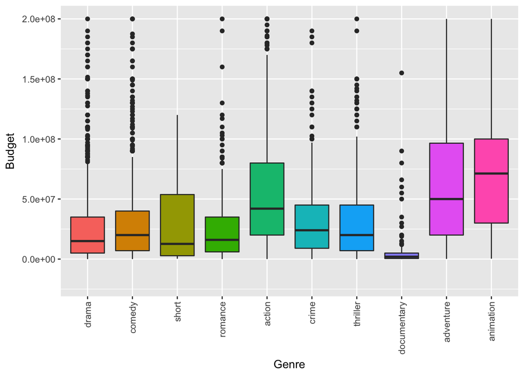

```r
# We have studied the Gross vs. Genre/Released_Month previously
# Here we will study Budget vs. Genre/Released_month

# Expected insight #1
temp = melt(df2, measure.vars = Top10$Genre,
              id.vars = c("Released_Month", "YearInDecades", "Budget"))
temp = temp[temp$value==1,]

ggplot(data = temp, aes(x = variable, y=Budget, fill=variable)) +
  geom_boxplot(na.rm = TRUE) +
  labs(x="Genre") +
  scale_y_continuous(limits = c(-20000000, 200000000)) +
  theme(axis.text.x=element_text(angle=90,hjust=1, vjust = 0.5),
        legend.position = "none")
```

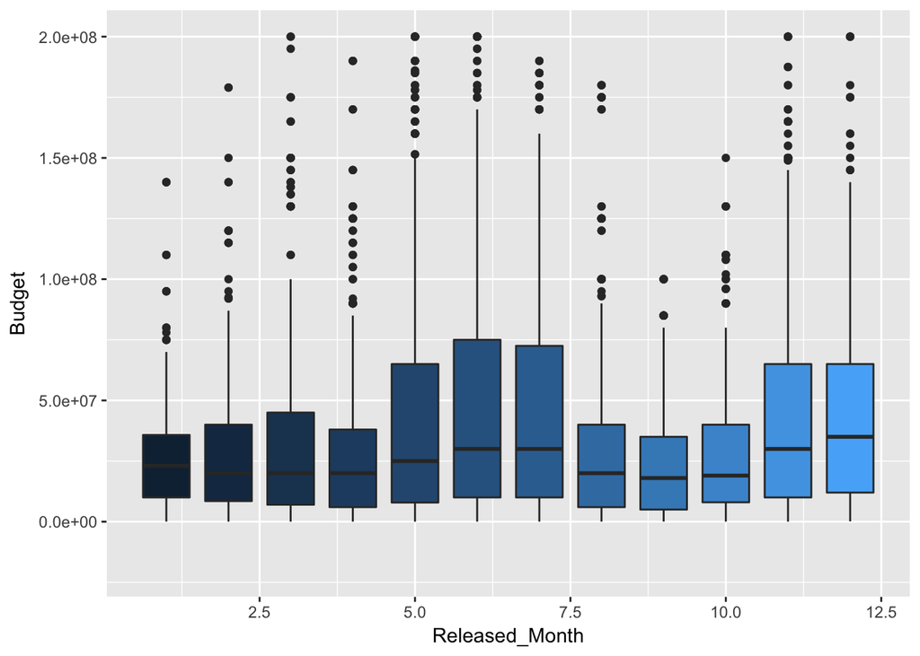

```r
# Expected insight #2
ggplot(data = temp, aes(x = Released_Month, y=Budget,
                          group = Released_Month, fill = Released_Month))  +
  geom_boxplot(na.rm = TRUE) +
  scale_y_continuous(limits = c(-20000000, 200000000)) +
  theme(legend.position = "none")
```

**Q**: Expected insight #1.

**A**: We have compared Gross vs. Top 10 Genre previously. Here we consider Budget vs Top 10 Genres. It’s evident that action, adventure and animation are the top 3 genre with highest median budget. This makes sense because it is reasonable to assume action or adventure movies will have higher cost. However, the animation movie has high budget is sort of unexpected though.

**Q**: Expected insight #2.

**A**: Similarly, if we compare Budget against the released month, one can see that movies that are targeted for the summer season or the holiday season (Nov & Dec) in general have higher budget. This is expected because more people will go to cinema during those seasons, and movies released during those reasons will have higher gross revenue as shown in the previous section.

## 10. Unexpected insight

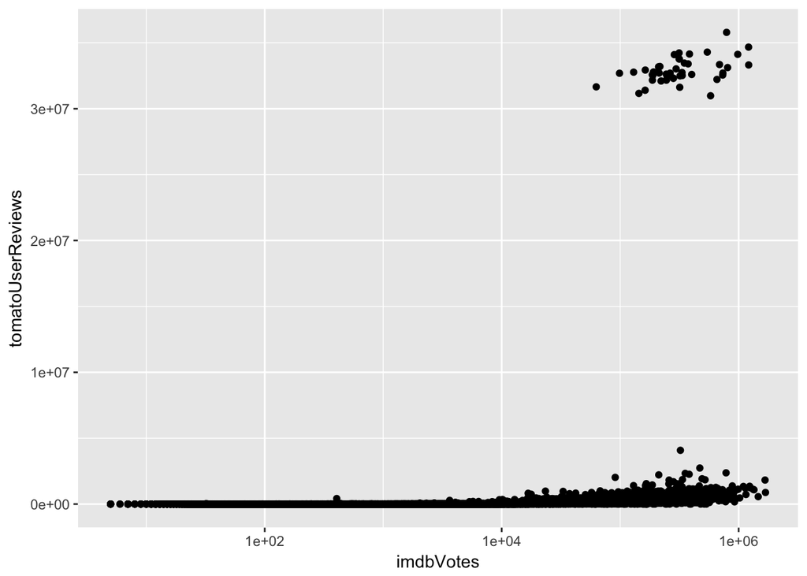

```r
# No. of User rating of IMDB vs. No. of User rating from Tomato
ggplot(data = df2, aes(x = imdbVotes, y = tomatoUserReviews)) +
  geom_point(na.rm = TRUE) +
  scale_x_log10()
```

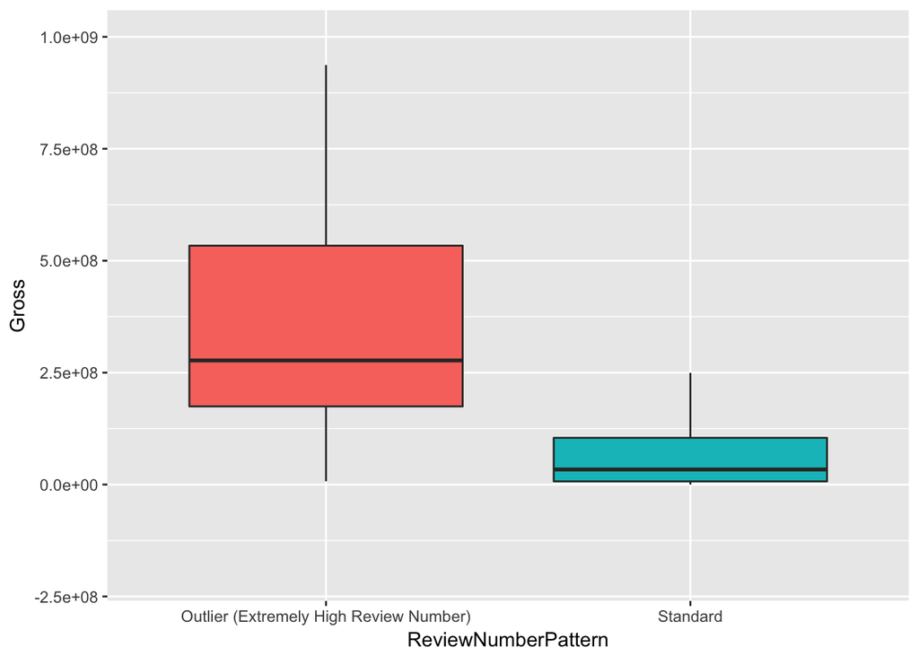

```r
# Study on the movies with outlier tomatoUser review number
idx1 = df2$tomatoUserReviews>20000000
idx1[is.na(idx1)] = FALSE
df2$ReviewNumberPattern[idx1] = "Outlier (Extremely High Review Number)"

idx2 = df2$tomatoUserReviews<20000000
idx2[is.na(idx2)] = FALSE
df2$ReviewNumberPattern[idx2] = "Standard"

# Study gross revenue
ggplot(data = df2[!is.na(df2$ReviewNumberPattern),],
       aes(x=ReviewNumberPattern,
           y=Gross,
           group = ReviewNumberPattern,
           fill = ReviewNumberPattern)) +
  geom_boxplot(na.rm = TRUE, outlier.shape = NA) +
  scale_y_continuous(limits = c(-200000000, 1000000000)) +
  theme(legend.position="none")
```

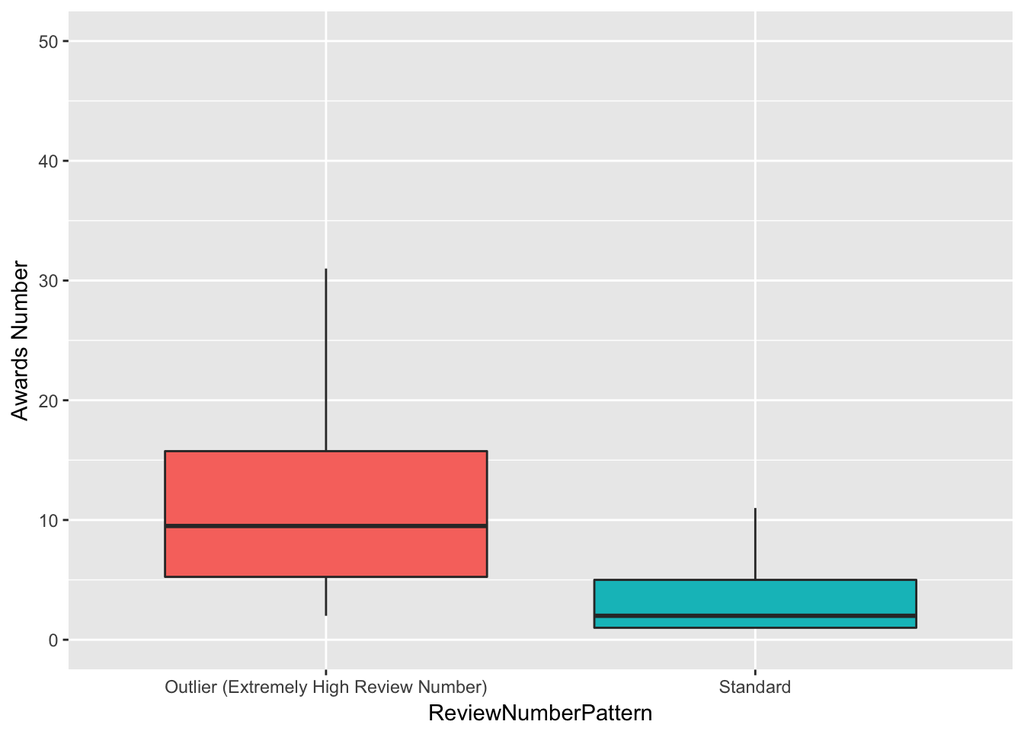

```r
# Study awards
ggplot(data = df2[!is.na(df2$ReviewNumberPattern),],
       aes(x=ReviewNumberPattern, y=wins,
           group = ReviewNumberPattern, fill = ReviewNumberPattern)) +
  geom_boxplot(na.rm = TRUE, outlier.shape = NA) +
  scale_y_continuous(limits = c(0, 50)) +
  labs( y = "Awards Number") +
  theme(legend.position="none")
```

**Analysis**: When comparing the number of user votes/reviews from either IMDB or Rottentomato, one would expect they should have similar distribution since they are both from the general public. Nevertheless, there is an evident bi-modal distribution for the tomato user reviews, indicating that there are some movies with extremely high number of reviews than the others at Rotten Tomato. I compared the Gross avenue and number of awards won by those “Outlier” movies, and I found that those movies have much higher avenue and have won more awards than the others. These two reason may explain why there are so many reviews for those movies at Rotten Tomato.